# Homework 10 Example - Admixture, PCA, and DAPC

Author

Nolan Helmstetter

# Viewing admixture results completed via the bash shell on tempest, using the tool admixture

Load admixture output

```r
# read sample names and extract
fam <- read_table("/home/g27n141/bioe-591-genomics/students/Helmstetter/hw_output/10/output/IDGS.int.fam",
                  col_names = FALSE,
                  show_col_types = FALSE
)

head(fam)
```

```
# A tibble: 6 × 6
     X1 X2         X3    X4    X5    X6
  <dbl> <chr>   <dbl> <dbl> <dbl> <dbl>
1     0 002         0     0     0    -9
2     0 003         0     0     0    -9
3     0 004         0     0     0    -9
4     0 16_0002     0     0     0    -9
5     0 16_0003     0     0     0    -9
6     0 16_0007     0     0     0    -9
```

Extract Individual IDs

```r
samples <- fam$X2   # individual IDs are usually column 2
```

Choose your K value (will be 2 for this demo)

```r
K <- 2
```

Read Q matrix: Ancestry proprtions for each individual

```r
q <- read_table("/home/g27n141/bioe-591-genomics/students/Helmstetter/hw_output/10/output/IDGS.int.2.Q",
                col_names = FALSE,
                show_col_types = FALSE
)

head(q)
```

```
# A tibble: 6 × 2
       X1      X2
    <dbl>   <dbl>
1 1.00    0.00001
2 1.00    0.00001
3 1.00    0.00001
4 0.00001 1.00
5 0.00001 1.00
6 0.00001 1.00
```

Name the ancestry columns

```r
colnames(q) <- paste0("Cluster", 1:K)
```

Combine with sample names

```r
q_df <- q %>%
  mutate(sample = samples) %>%
  relocate(sample)
head(q_df)
```

```
# A tibble: 6 × 3
  sample  Cluster1 Cluster2
  <chr>      <dbl>    <dbl>
1 002      1.00     0.00001
2 003      1.00     0.00001
3 004      1.00     0.00001
4 16_0002  0.00001  1.00
5 16_0003  0.00001  1.00
6 16_0007  0.00001  1.00
```

Convert to long format for ggplot

```r
q_long <- q_df %>%
  pivot_longer(
    cols = starts_with("Cluster"),
    names_to = "cluster",
    values_to = "ancestry"
  ) %>%
  mutate(sample = factor(sample, levels = samples))
head(q_long)
```

```
# A tibble: 6 × 3
  sample cluster  ancestry
  <fct>  <chr>       <dbl>
1 002    Cluster1  1.00
2 002    Cluster2  0.00001
3 003    Cluster1  1.00
4 003    Cluster2  0.00001
5 004    Cluster1  1.00
6 004    Cluster2  0.00001
```

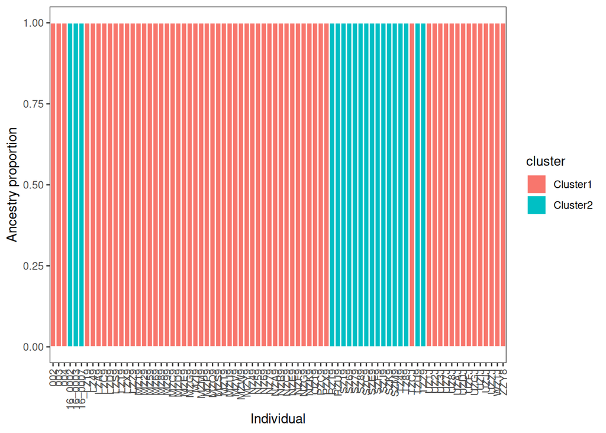

```r
# plot
ggplot(q_long, aes(x = sample, y = ancestry, fill = cluster)) +
  geom_col(width = 1, color="white") +
  theme_bw() +
  labs(x = "Individual", y = "Ancestry proportion") +
  theme(
    panel.grid = element_blank(),
    axis.text.x = element_text(angle = 90, vjust = 0.5, hjust = 1)
  )
```

Use regex functions in R to extract our cross-validation values. CV values are hidden in the .out files.

```r
cv_df <- tibble(file = "/home/g27n141/bioe-591-genomics/students/Helmstetter/hw_output/10/log/admix_step2-3840151.out") %>%
  mutate(
    text = map_chr(file, read_file),
    cv_line = str_extract(text, "CV error \\(K=\\d+\\):\\s*[-0-9.eE]+"),
    K  = str_match(cv_line, "CV error \\(K=(\\d+)\\)")[,2] |> as.integer(),
    CV = str_match(cv_line, ":\\s*([-0-9.eE]+)")[,2] |> as.numeric()
  ) %>%
  select(file, K, CV) %>%
  arrange(K)
```

# Plot samples and ancestry percentage in space

```r
# Load CSV File
csv <- read_csv("/home/g27n141/bioe-591-genomics/students/Helmstetter/hw_output/10/data/IDGS_BIOCLIM_Land_Soil_all_ed.csv", col_names = TRUE, show_col_types = FALSE
)

# Rename ID as sample
csv <- csv %>%
  rename(sample = ID)
```

Merge dfs for plotting

```r
q_df2 <- q_df %>%
  left_join(csv %>% select(sample, Lat, Long), by = "sample")
```

Make df into an sf object for plotting in space.

```r
q_sf <- st_as_sf(q_df2, coords = c("Long", "Lat"), crs = 4326)
```

Plot as pie chart showing ancestry (I just did this for some marten data) :)

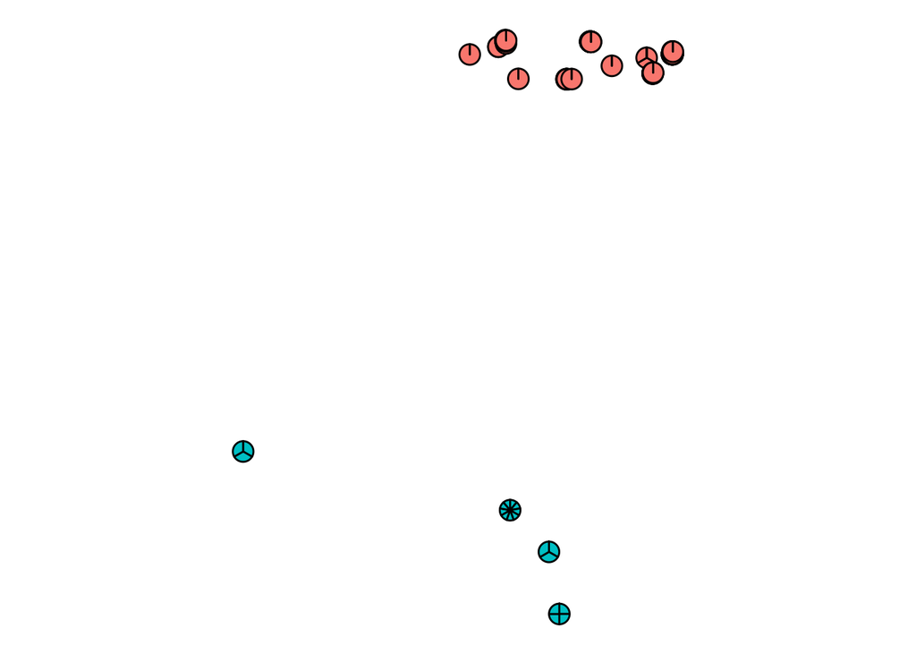

```r
ggplot() +
  geom_scatterpie(
    data = q_df2,
    aes(x = Long, y = Lat),
    cols = c("Cluster1", "Cluster2"),
    pie_scale = 1.2,
    color = "black"
  ) +
  coord_equal() +
  theme_void() +
  theme(legend.position = "none")
```

# Running a PCA

Load .vcf data

```r
vcf <- read.vcfR(
  file = "/home/g27n141/bioe-591-genomics/students/Helmstetter/hw_output/10/data/IDGS.recode.vcf",
  verbose = TRUE
)
```

[output not shown]

Converts genotpyes in VCF and makes a DNbin object. A, C, G, T for each individual.

```r
dna <- vcfR2DNAbin(vcf, unphased_as_NA = F, consensus = T, extract.haps = F)
```

```
After extracting indels, 4227 variants remain.
```

```r
species_genind <- DNAbin2genind(dna)
species_genind
```

```
/// GENIND OBJECT /////////

 // 80 individuals; 2,084 loci; 4,168 alleles; size: 2.3 Mb

 // Basic content
   @tab:  80 x 4168 matrix of allele counts
   @loc.n.all: number of alleles per locus (range: 2-2)
   @loc.fac: locus factor for the 4168 columns of @tab
   @all.names: list of allele names for each locus
   @ploidy: ploidy of each individual  (range: 1-1)
   @type:  codom
   @call: DNAbin2genind(x = dna)

 // Optional content
   - empty -
```

Deal with missing data and center genotypes (i.e., make laternative homozygotes equivalent, not translate to numierc values of 0 or 2 based on their allele count). Then run PCA on data.

```r
species_genind_scaled <- scaleGen(species_genind,NA.method="mean",scale=F)
species_pca <- prcomp(species_genind_scaled, center=F,scale=F)
```

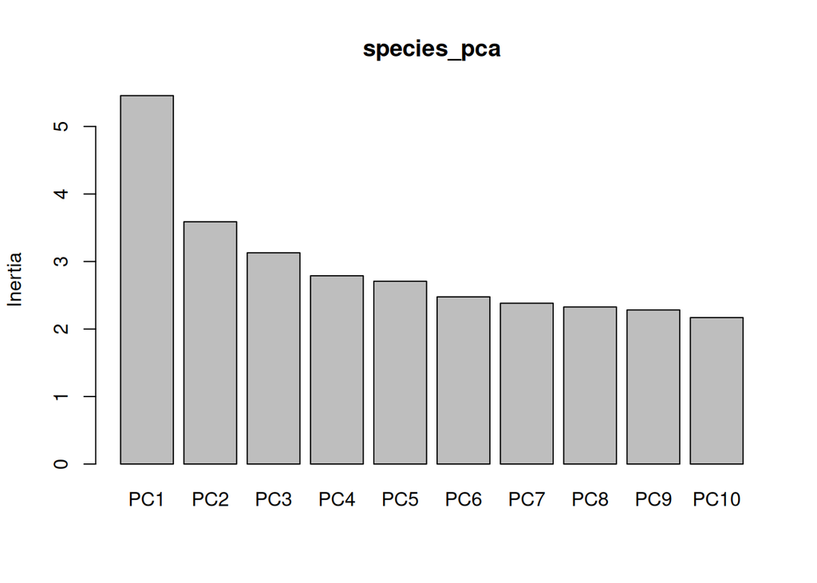

```r
screeplot(species_pca)
```

Plotting individuals in PC1 and PC2 space. Seperate by species. As expected, southern Idaho ground squirrels have more genetic variation than the smaller, isolated Northern Idaho ground squirrel populations.

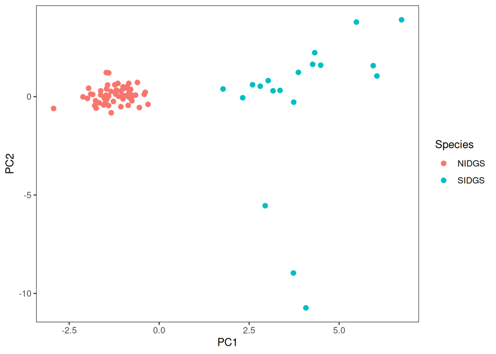

```r
pc <- data.frame(species_pca$x[,1:3])
pc$sample <- rownames(pc)

# Get speies from csv for each sample
pc <- pc %>%
  left_join(csv %>% select(sample, Species), by = "sample")

# Plot seperated by species
ggplot(pc, aes(x = PC1, y = PC2, color = Species)) +
  geom_point(size = 2) +
  theme_bw()+
  theme(panel.grid = element_blank())
```

# Running a Discriminant Analysis of Principal Components (DAPC)

Assign samples distinct, nonoverlapping clusters based on similarity in in PC space

```r
grp <- find.clusters(species_genind, n.pca = 50, n.clust = 2)
grp
```

```
$Kstat
NULL

$stat
NULL

$grp
    002     003     004 16_0002 16_0003 16_0007    LZ19    LZ49    LZA9    LZC9
      1       1       1       2       2       2       1       1       1       1
   LZD9    LZS9    LZT9    LZX9    LZZ9    MZ19    MZ29    MZ59    MZ69    MZ89
      1       1       1       1       1       1       1       1       1       1
   MZ99    MZC9    MZD9    MZE9    MZG9    MZI9    MZM9    MZP9    MZQ9    MZS9
      1       1       1       1       1       1       1       1       1       1
   MZT9    MZU9    MZV9    MZW9    MZY9    NZ49    NZ59    NZ69    NZ79    NZA9
      1       1       1       1       1       1       1       1       1       1
   NZB9    NZC9    NZE9    NZF9    NZG9    NZK9    OZ19    PZC9    PZX9    RZT9
      1       1       1       1       1       1       1       1       1       2
   RZU9    SZ19    SZ69    SZ79    SZ89    SZC9    SZE9    SZF9    SZJ9    SZK9
      2       2       2       2       2       2       2       2       2       2
   SZM9    TZ49    TZ89    TZCJ    TZU9    TZZ9    UZ1J    UZ2J    UZ3J    UZ7J
      2       2       2       1       2       2       1       1       1       1
   UZ8J    UZAJ    UZDJ    UZFJ    UZGJ    UZIJ    UZJJ    UZZJ    WZ1J    ZZY8
      1       1       1       1       1       1       1       1       1       1
Levels: 1 2

$size
[1] 61 19
```

Plot samples in PC1 and PC2 space seperating by defined clusters (above)

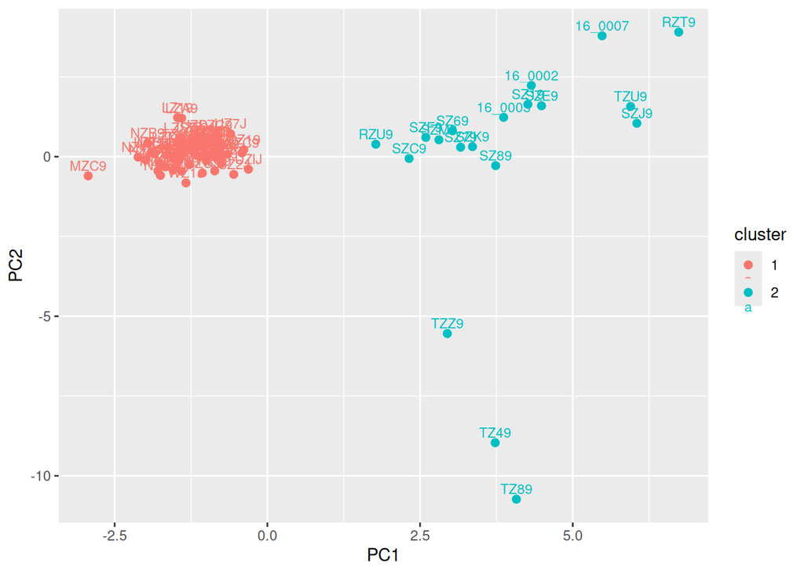

```r
pc$cluster <- grp$grp
ggplot(pc, aes(x = PC1, y = PC2, color = cluster)) +
  geom_point(size = 2) +
  geom_text(aes(label = sample), vjust = -0.5, size = 3)
```

DAPC takes these hard-coded assignments and determines which principal components contribute to them, as well as any uncertainty in ancestry. (It is thus designed to discriminate on the basis of user-input populations, and should be used in combination with -means clustering or other approaches for detecting and / or designating structure.)

```r
# Keeps 50 principal components, Finds axes that maximize between-group differences for n.da = 2 groups
# na.da = 2 means we are asking for two discriminant axes, but since k = 2 groups, only 1 meaingful axis exists.
# We want to maximize variation between groups and minimize variation within groups
# Gives probabilities of each individual belonging to each group

dapc1 <- dapc(species_genind, pop = grp$grp, n.pca = 50, n.da = 2)
dapc1
```

```
    #################################################
    # Discriminant Analysis of Principal Components #
    #################################################
class: dapc
$call: dapc.genind(x = species_genind, pop = grp$grp, n.pca = 50, n.da = 2)

$n.pca: 50 first PCs of PCA used
$n.da: 1 discriminant functions saved
$var (proportion of conserved variance): 0.775

$eig (eigenvalues): 2986  vector    length content
1 $eig      1      eigenvalues
2 $grp      80     prior group assignment
3 $prior    2      prior group probabilities
4 $assign   80     posterior group assignment
5 $pca.cent 4168   centring vector of PCA
6 $pca.norm 4168   scaling vector of PCA
7 $pca.eig  79     eigenvalues of PCA

  data.frame    nrow ncol content
1 $tab          80   50   retained PCs of PCA
2 $means        2    50   group means
3 $loadings     50   1    loadings of variables
4 $ind.coord    80   1    coordinates of individuals (principal components)
5 $grp.coord    2    1    coordinates of groups
6 $posterior    80   2    posterior membership probabilities
7 $pca.loadings 4168 50   PCA loadings of original variables
8 $var.contr    4168 1    contribution of original variables
```

The important part of this output are the posterior probabilities of ancestry assignments. We will extract these and turn it into a tibble with sample name, cluster, and ancestry probability: Looks analgous to our admixture results.

```r
q <- as.data.frame(dapc1$posterior)
  q$sample <- rownames(q)
  q_long <- q |>
    pivot_longer(
      cols = -sample,
      names_to = "cluster",
      values_to = "ancestry"
    )
q_long
```

```
# A tibble: 160 × 3
   sample  cluster ancestry
   <chr>   <chr>      <dbl>
 1 002     1       1   e+ 0
 2 002     2       7.57e-39
 3 003     1       1   e+ 0
 4 003     2       1.04e-49
 5 004     1       1   e+ 0
 6 004     2       1.54e-46
 7 16_0002 1       1.05e-47
 8 16_0002 2       1   e+ 0
 9 16_0003 1       2.19e-50
10 16_0003 2       1   e+ 0
# ℹ 150 more rows
```

Plot ancestry estimates from DAPC

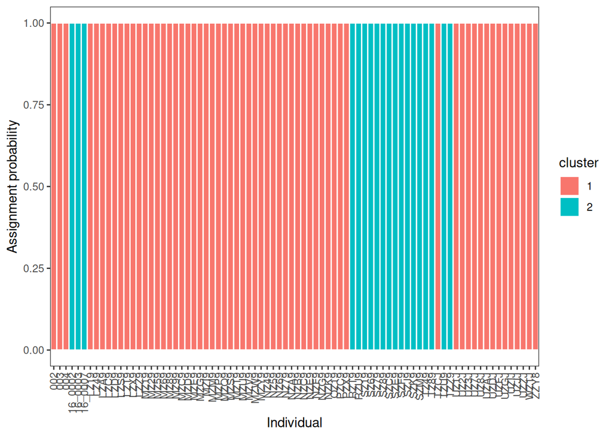

```r
ggplot(q_long, aes(x = sample, y = ancestry, fill = cluster)) +
  geom_col(width = 1, color = "white") +
  theme_bw() +
  labs(x = "Individual", y = "Assignment probability") +
  theme(
    panel.grid = element_blank(),
    axis.text.x = element_text(angle = 90, vjust = 0.5, hjust = 1)
  )
```

Compare results across differetn values of K Uses BIC to evaluate results (i.e., model fit vs model complexity). This is not running a bayesian analysis despite using BIC.

```r
# Identify clusters
grp_auto <- find.clusters(
  species_genind,
  n.pca = 50,
  choose.n.clust = FALSE,
  max.n.clust = 10,
  stat = "BIC"
)

# Print BIC values
grp_auto$Kstat
```

```
     K=1      K=2      K=3      K=4      K=5      K=6      K=7      K=8
365.2108 365.0958 366.3905 368.4601 369.9612 371.9081 373.7892 376.2656
     K=9     K=10
377.9438 380.1328
```

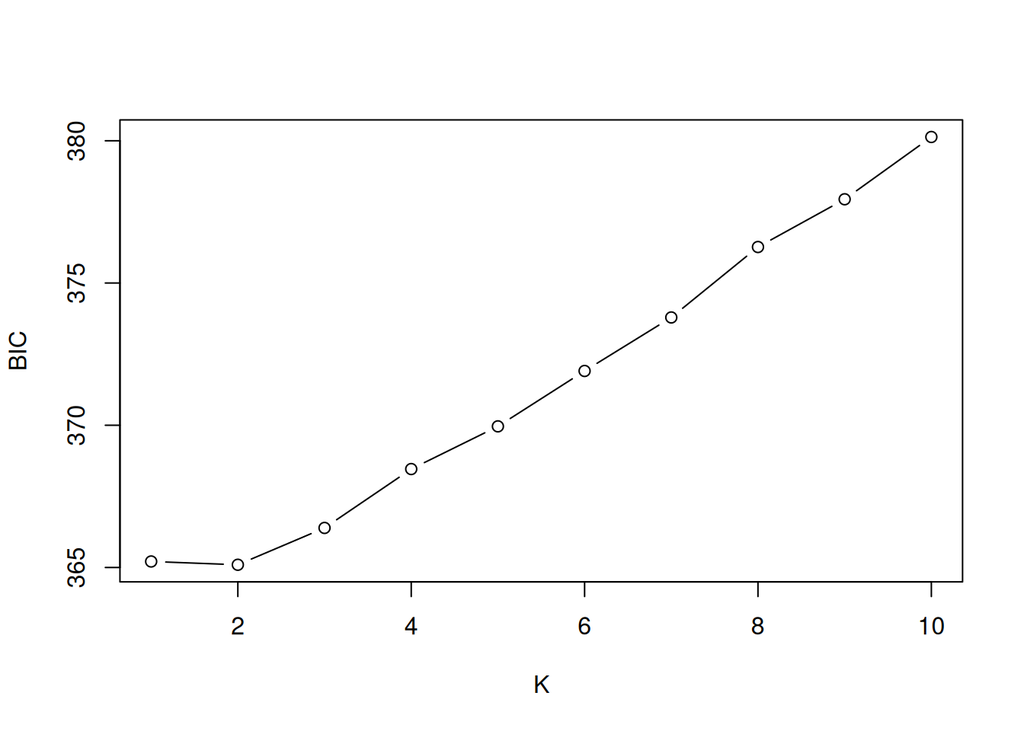

```r
# plot!
plot(
  1:length(grp_auto$Kstat),
  grp_auto$Kstat,
  type = "b",
  xlab = "K",
  ylab = "BIC"
)
```